# Leaf classifier: results

Which classifier best predicts the tree type from leaf height and width, and how well does it do on unseen data?

0.884

test balanced accuracy, k-NN

0.946

cross-validated balanced accuracy

0.333

baseline (always the largest class)

-0.061

test minus CV

## Data

`data/leaves.csv`: 518 rows (216 maple, 173 cherry, 129 walnut). After removing 26 exact duplicate rows, 492 rows were split 80 / 20 %, stratified by class (seed 42), into 393 training rows and 99 test rows.

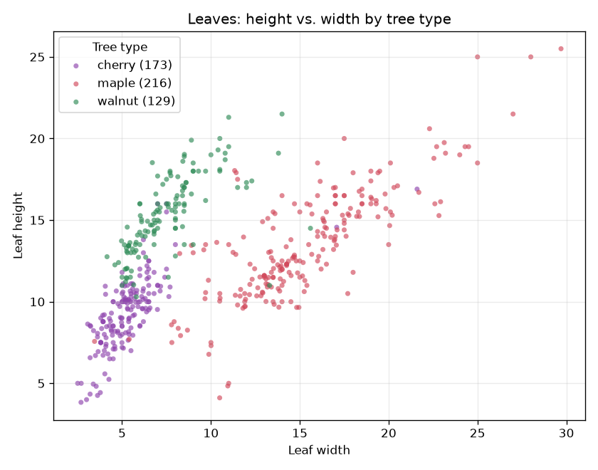

## Model comparison (cross-validation, training rows only)

5 models and the baseline, 108 grid points in total, each scored with 5-fold stratified cross-validation on balanced accuracy.

| Model | Grid points | CV balanced accuracy | Best settings | vs. baseline | Chosen |
| --- | --- | --- | --- | --- | --- |
| baseline | 1 | 0.333 ± 0.000 | – | – |  |
| logistic regression | 7 | 0.929 ± 0.043 | C = 1.0 | +0.596 |  |
| decision tree | 10 | 0.931 ± 0.018 | max_depth = 5 | +0.598 |  |
| k-NN | 30 | 0.946 ± 0.030 | n_neighbors = 9 | +0.613 | ✔ |
| SVM (RBF) | 36 | 0.942 ± 0.030 | C = 100.0, gamma = 0.1 | +0.609 |  |
| random forest | 24 | 0.938 ± 0.027 | max_depth = 8, min_samples_leaf = 1 | +0.605 |  |

The baseline scores 0.333. The real models range from 0.929 to 0.946, a spread smaller than their CV standard deviations (0.018–0.043). Models within 0.01 of the best (k-NN, SVM (RBF), random forest) count as tied and the simplest wins: **k-NN (n_neighbors = 9)**.

## Test set (used once)

| Model | CV balanced accuracy | Test balanced accuracy | 95 % CI | Test accuracy | Test macro F1 | Test − CV |
| --- | --- | --- | --- | --- | --- | --- |
| baseline | 0.333 ± 0.000 | 0.333 | – | 0.424 | 0.199 | +0.000 |
| k-NN | 0.946 ± 0.030 | 0.884 | 0.813–0.948 | 0.899 | 0.887 | -0.061 |

On the 99 test rows k-NN reaches a balanced accuracy of **0.884** (accuracy 0.899, macro F1 0.887), 0.061 below its CV estimate of 0.946 ± 0.030. The baseline scores 0.333.

The 95 % confidence interval of the test balanced accuracy is **0.813–0.948** (percentile bootstrap of the saved test predictions, 10,000 resamples drawn within each class, seed 42). The CV estimate lies inside it.

### Confusion matrix (k-NN, test set)

| true class (rows) | predicted cherry | predicted maple | predicted walnut | recall |
| --- | --- | --- | --- | --- |
| cherry (33) | 30 | 1 | 2 | 0.909 |
| maple (42) | 1 | 40 | 1 | 0.952 |
| walnut (24) | 4 | 1 | 19 | 0.792 |

Recall per class: cherry 0.909, maple 0.952, walnut 0.792. The weakest class is **walnut**; 4 of its test rows were predicted as cherry. 10 of 99 test rows were predicted wrong.

## Notes

3 of the 8 suspicious rows from the data report (conflicting labels or a cherry inside the maple cluster) landed in the test set (file lines 497, 216, 386); 3 of them were predicted wrong.

Generated by `ml-study/make_report.py` from `ml-study/results/*.csv`, `ml-study/figures/scatter.png` and `data/leaves.csv`.